# project

### Introduction

This udacity project is related to kaggle competetion at https://www.kaggle.com/donorschoose/io/home and I use the same dataset provided for the above compettion.

#### import all the required for executing the code

```python
from sklearn.feature_extraction.text import TfidfVectorizer
from sklearn.metrics.pairwise import linear_kernel
from sklearn.metrics.pairwise import cosine_similarity
import matplotlib.pyplot as plt
from sklearn.metrics.pairwise import linear_kernel
from multiprocessing import Pool

# other python utilities
from tqdm import tqdm
from tqdm import tqdm_notebook
import pandas as pd
import numpy as np
import warnings, math
import gc
%matplotlib inline
# ignore the warnings
warnings.filterwarnings('ignore')
```

#### Constants declarations

The constants declaration

```python
# This will be used to derive the related projects dataframe
output_columns=['Project ID', 'Related Project ID', 'Cosine Similarity']
# This is representative of top n related projects generated as output defaults to 5. Changeable to any useful value
top_n = 5
#number of partitions to split dataframe. This is primaraily used for parallel processing
num_partitions = 40
#number of cores on your machine. The more the value, more CPUs will be engaged for processing
num_cores = 2
# round off digits for final cosine similarity score.
round_digits=2
#filter condition for cosine simialrity score for related projects.
cos_filter_score=0.7
```

#### Set Panda Options

Utility method for setting panda options are set to display pandas dataframe

```python
def set_pd_options():
    pd.set_option('display.max_rows', 500)
    pd.set_option('display.max_columns', 500)
    pd.set_option('display.width', 1000)
```

#### 1.1 Set Panda display column width

Utility method for setting panda options for displaying long columns

```python
def set_column_width():
    pd.set_option('display.max_colwidth', -1)
```

#### Load Dataset

Load the dataset files into pandas dataframe. I am using projects dataset for the purpose of this project which resides in the io folder

```python
path = "./io/"
projects_df = pd.read_csv(path +"Projects.csv")
set_pd_options()
projects_df.head()
```

|  | Project ID | School ID | Teacher ID | Teacher Project Posted Sequence | Project Type | Project Title | Project Essay | Project Short Description | Project Need Statement | Project Subject Category Tree | Project Subject Subcategory Tree | Project Grade Level Category | Project Resource Category | Project Cost | Project Posted Date | Project Expiration Date | Project Current Status | Project Fully Funded Date |
| --- | --- | --- | --- | --- | --- | --- | --- | --- | --- | --- | --- | --- | --- | --- | --- | --- | --- | --- |
| 0 | 7685f0265a19d7b52a470ee4bac883ba | e180c7424cb9c68cb49f141b092a988f | 4ee5200e89d9e2998ec8baad8a3c5968 | 25 | Teacher-Led | Stand Up to Bullying: Together We Can! | Did you know that 1-7 students in grades K-12 ... | Did you know that 1-7 students in grades K-12 ... | My students need 25 copies of "Bullying in Sch... | Applied Learning | Character Education, Early Development | Grades PreK-2 | Technology | 361.80 | 2013-01-01 | 2013-05-30 | Fully Funded | 2013-01-11 |
| 1 | f9f4af7099061fb4bf44642a03e5c331 | 08b20f1e2125103ed7aa17e8d76c71d4 | cca2d1d277fb4adb50147b49cdc3b156 | 3 | Teacher-Led | Learning in Color! | Help us have a fun, interactive listening cent... | Help us have a fun, interactive listening cent... | My students need a listening center, read alon... | Applied Learning, Literacy & Language | Early Development, Literacy | Grades PreK-2 | Technology | 512.85 | 2013-01-01 | 2013-05-31 | Expired | NaN |
| 2 | afd99a01739ad5557b51b1ba0174e832 | 1287f5128b1f36bf8434e5705a7cc04d | 6c5bd0d4f20547a001628aefd71de89e | 1 | Teacher-Led | Help Second Grade ESL Students Develop Languag... | Visiting or moving to a new place can be very ... | Visiting or moving to a new place can be very ... | My students need beginning vocabulary audio ca... | Literacy & Language | ESL | Grades PreK-2 | Supplies | 435.92 | 2013-01-01 | 2013-05-30 | Fully Funded | 2013-05-22 |
| 3 | c614a38bb1a5e68e2ae6ad9d94bb2492 | 900fec9cd7a3188acbc90586a09584ef | 8ed6f8181d092a8f4c008b18d18e54ad | 40 | Teacher-Led | Help Bilingual Students Strengthen Reading Com... | Students at our school are still working hard ... | Students at our school are still working hard ... | My students need one copy of each book in The ... | Literacy & Language | ESL, Literacy | Grades 3-5 | Books | 161.26 | 2013-01-01 | 2013-05-31 | Fully Funded | 2013-02-06 |
| 4 | ec82a697fab916c0db0cdad746338df9 | 3b200e7fe3e6dde3c169c02e5fb5ae86 | 893173d62775f8be7c30bf4220ad0c33 | 2 | Teacher-Led | Help Us Make Each Minute Count! | "Idle hands" were something that Issac Watts s... | "Idle hands" were something that Issac Watts s... | My students need items such as Velcro, two pou... | Special Needs | Special Needs | Grades 3-5 | Supplies | 264.19 | 2013-01-01 | 2013-05-30 | Fully Funded | 2013-01-01 |

#### Cleanup Dataset

Cleanup the dataset to enable the data to be used correctly.

```python
# clean up missing values
projects_df['Project Essay'].fillna("", inplace = True)
projects_df['Project Short Description'].fillna("", inplace = True)

## Create some additional features in projects data
projects_df['cost'] = projects_df['Project Cost']\
                      .apply(lambda x : float(str(x).replace("$","").replace(",","")))
projects_df['Posted Date'] = pd.to_datetime(projects_df['Project Posted Date'])
projects_df['Posted Year'] = projects_df['Posted Date'].dt.year
projects_df['Posted Month'] = projects_df['Posted Date'].dt.month

print(projects_df.columns)
```

```
Index(['Project ID', 'School ID', 'Teacher ID', 'Teacher Project Posted Sequence', 'Project Type', 'Project Title', 'Project Essay', 'Project Short Description', 'Project Need Statement', 'Project Subject Category Tree', 'Project Subject Subcategory Tree', 'Project Grade Level Category', 'Project Re…
```

#### Query Fields of Interest

We need to identify the project current status whch will determine whether or a project needs to be identified with related projects.

```
Unique Project Statuses ['Fully Funded' 'Expired' 'Live']
```

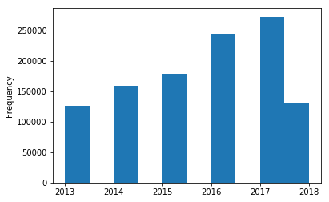

```python
print("Unique Project Statuses", projects_df['Project Current Status'].unique())
projects_df["Posted Year"].plot(kind='hist')
```

#### Find record counts for Project Current Status Column

We need to identify the record count associated with project current status.

```python
print(projects_df[["Project ID", 'Project Current Status']].groupby('Project Current Status').count())
```

```
                        Project ID
Project Current Status
Expired                     241402
Fully Funded                826764
Live                         41851
```

#### Pick records with Project Current Status Column with Live values

The user is presented with live projects and this project is being done with the sole purpose of presenting the users with associated projects. Here we picking up projects which have project current status as live.

```python
active_projects_df=projects_df[projects_df['Project Current Status']=='Live']
active_projects_df.reset_index(inplace=True)
del projects_df
gc.collect()
print("size of active project", active_projects_df.shape)
```

```
size of active project (41851, 23)
```

#### verify that column Project Essay has correct number of records with Project Current Status Column with Live values

The number of records with project essay is consistent with total records with project current status as live

```python
print(active_projects_df[['Project Short Description', 'Project Essay', 'Project Current Status']].groupby('Project Current Status').count())
```

```
                        Project Short Description  Project Essay
Project Current Status
Live                                        41851          41851
```

#### Display the number of years spanned by the records with project current status

Display the number of year spanned by records having project current status as live

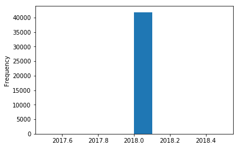

```python
active_projects_df["Posted Year"].plot(kind='hist')
```

#### Derive all the values of project essay column

Derive the project essay column values to be used for cosine similarity

```python
set_column_width()
project_essay = active_projects_df['Project Short Description'] + active_projects_df['Project Essay']
print(project_essay[4:5])
```

```
4    My students have chosen to be a part of a small charter school that was founded on principles of hard work, determination, and the betterment of education. \nMy music program is only four years...My students have chosen to be a part of a small charter school that was founded on principles of ha…
dtype: object
```

#### Train project essay values

Using TfidfVectorizer train the project_essay values to derive tfidf_matrix

```python
vectorizer = TfidfVectorizer(strip_accents='unicode',
                     analyzer='word',
                     lowercase=True, # Convert all uppercase to lowercase
                     stop_words='english', # Remove common English words
                     sublinear_tf=False, # use linear weightage for term frequency
                     max_df = 0.9)
tfidf_matrix =  vectorizer.fit_transform(project_essay)
```

#### Utility method to derive the project id

Given an index, the method identifies the project id associated with this index

```python
def get_project_id(index):
    return active_projects_df.at[index,  'Project ID']
```

#### Given an index, this function will return all the related projects

Given an index as a parameter, this function will return all the related projects using the tfidf_matrix derived earlier

```python
def get_similar_projects(index):
    cosine_similarities = linear_kernel(tfidf_matrix[index:index+1], \
                                        tfidf_matrix).flatten()
    related_docs_indices = [i for i in cosine_similarities.argsort()\
                            [::-1][:top_n + 1] if i != index]
    list_data=[( get_project_id(index), get_project_id(row_index), \
                round(cosine_similarities[row_index], round_digits)) \
               for row_index in related_docs_indices[0:top_n]]
    return list_data
```

#### Given a DataFrame, it iterates thru the rows to derive the related projects

Given a DataFrame, it iterates thru the rows to derive the related projects. This is utilized in the context of paritioning the dataframe and process them independently

```python
def find_similar_projects(data_frame):
    output=[]
    for index in tqdm(data_frame.index.values.tolist()):
#     for index in tqdm(data_frame.index.values[:1000]):
        project_list=get_similar_projects(index)
        output.extend(project_list)
    return pd.DataFrame(output, columns=output_columns)
```

#### The function will parallel process the dataframe

The function will parallel process the dataframe by partioning it and process them parallely using multiprocessing pool

```python
def parallel_process_dataframe(df, func):
    df_split = np.array_split(df, num_partitions)
    pool = Pool(num_cores)
    df = pd.concat(pool.map(func, df_split))
    pool.close()
    pool.join()
    return df
```

#### This procedure invokes paralel processing of dataframe

This procedure invokes paralel processing of dataframe by passing active_projects_df and the function name to used for parallel processing to derive the related projects

```python
related_projects_df = parallel_process_dataframe(active_projects_df, find_similar_projects)
print(related_projects_df.shape)
print(related_projects_df.head(20))
```

```
(209255, 3)
                          Project ID                Related Project ID  Cosine Similarity
0   486b625006d71ab21f8592463608e42d  8465aafe5f00b6937d9e251f96ac2d7d  0.30
1   486b625006d71ab21f8592463608e42d  6dab3d09d42c37a10a8842e9d6b3e40d  0.30
2   486b625006d71ab21f8592463608e42d  785f90f2228eb19c83f7b2e3638ca888  0.30
3   486b625006d71ab21f8592463608e42d  8d167a560d79a6190cf2136a75d8fd00  0.30
4   486b625006d71ab21f8592463608e42d  51c1892a679be303cf9fc7e2b5a00ef0  0.28
5   d386d5f58d0388b62b7a7b06e99d1afb  90388cc252d97ed91446b56562b9e3f9  0.32
6   d386d5f58d0388b62b7a7b06e99d1afb  67ac18693559e72c195c22eada4ac3c1  0.27
7   d386d5f58d0388b62b7a7b06e99d1afb  f5011a9816695807c8990af6618a44f8  0.26
8   d386d5f58d0388b62b7a7b06e99d1afb  e32251cf79b3bb2f2cdc55350b5b459a  0.22
9   d386d5f58d0388b62b7a7b06e99d1afb  72f10e4da5b68fa138ab96c6f5d6f55a  0.22
10  abd2631ada10761150684d6a4948c802  a970f22fba20601094d1b1c722b47626  0.38
11  abd2631ada10761150684d6a4948c802  a4f5aa5b36aa7d3abc35f6e29c2656d5  0.38
12  abd2631ada10761150684d6a4948c802  0e66290bc7e9b691e3d65bfa95902e47  0.33
13  abd2631ada10761150684d6a4948c802  3f387acdfdd0ab40d5b3b5e910f935ce  0.33
14  abd2631ada10761150684d6a4948c802  04cfcc1923ef5ea7d84c54dcb981eca4  0.33
15  af65b9205616bd482d94de31648d6cd1  44835355fcbab1721d49be26cb7dad31  0.91
16  af65b9205616bd482d94de31648d6cd1  a531e6ff4d02e8af2450b105dd869f46  0.42
17  af65b9205616bd482d94de31648d6cd1  3196596dca23769ba2b8ec73a37bfe43  0.37
18  af65b9205616bd482d94de31648d6cd1  2016dcbbb69d9ac02f383c665505cb7d  0.36
19  af65b9205616bd482d94de31648d6cd1  0dc51266ce031b0997689ea3d0ed89d1  0.36
```

#### Peristence of related projects data frame

Here we save the results as a file. However, in real life situations, it can be persisted in a database.

```python
related_projects_df.to_csv(path +"Related Projects.csv")
```

#### Merging of active_projects_df with related_projects_df

Here we apply apply minimum cosine similarity score & merge of active_projects_df with related_projects_df to derive the overall dataset to show related projects in the context of projects dataframe

```python
related_projects_df = related_projects_df[related_projects_df['Cosine Similarity'] > cos_filter_score]
merged_df=active_projects_df.merge( related_projects_df, on='Project ID', how='inner')
```

#### show the results of merged dataset sample

```python
merged_df.head(10)
```

|  | index | Project ID | School ID | Teacher ID | Teacher Project Posted Sequence | Project Type | Project Title | Project Essay | Project Short Description | Project Need Statement | Project Subject Category Tree | Project Subject Subcategory Tree | Project Grade Level Category | Project Resource Category | Project Cost | Project Posted Date | Project Expiration Date | Project Current Status | Project Fully Funded Date | cost | Posted Date | Posted Year | Posted Month | Related Project ID | Cosine Similarity |
| --- | --- | --- | --- | --- | --- | --- | --- | --- | --- | --- | --- | --- | --- | --- | --- | --- | --- | --- | --- | --- | --- | --- | --- | --- | --- |
| 0 | 1045742 | af65b9205616bd482d94de31648d6cd1 | a32fcd039389bde710c4c648e326fcd9 | 3dfc673e3d9f2b0fdce11431b3923a7c | 3 | Teacher-Led | Help Us Get Our Apps Together! | As a teacher in a low-income/high poverty school district in Chicago , my students are faced with several challenges both in and out of the classroom. My students are diverse learners who have communi… | As a teacher in a low-income/high poverty school district in Chicago , my students are faced with several challenges both in and out of the classroom. My students are diverse learners who have... | My students need access to one on one iPad opportunities to support differentiated learning experiences! | Literacy & Language, Special Needs | Literacy, Special Needs | Grades PreK-2 | Computers & Tablets | 490.53 | 2018-03-28 | 2018-07-28 | Live | NaN | 490.53 | 2018-03-28 | 2018 | 3 | 44835355fcbab1721d49be26cb7dad31 | 0.91 |
| 1 | 1045743 | b6b112d04ea19e3f81f70624f52db567 | 25179c14ba44ff25fa88468787b31825 | 26c94e4b0711ca01e4cd7a6d5c25011e | 4 | Teacher-Led | Homeless Music Searching For Choir Folders | My students have chosen to be a part of a small charter school that was founded on principles of hard work, determination, and the betterment of education. \nMy music program is only four years old, b… | My students have chosen to be a part of a small charter school that was founded on principles of hard work, determination, and the betterment of education. \nMy music program is only four years... | My students need folders to keep their music organized and in good condition. | Music & The Arts | Music, Performing Arts | Grades 6-8 | Classroom Basics | 441.06 | 2018-03-28 | 2018-07-28 | Live | NaN | 441.06 | 2018-03-28 | 2018 | 3 | c49aa5b2fcb90532dbface231221fb98 | 0.73 |
| 2 | 1045769 | 7213bfdd20378d5650a6b4392fa479ae | a0b70d8c096f3158efef161a346abdd9 | 5bb78aa64eb0d9ea25a25f4d8e17840a | 3 | Teacher-Led | Help Us Move and Work at the Same Time! | Many students in my school speak English as a Second Language. Also, many students in the school live below the poverty line. Still, despite all of these challenges, they come to school every day with… | Many students in my school speak English as a Second Language. Also, many students in the school live below the poverty line. Still, despite all of these challenges, they come to school every day... | My students need alternative seating to help them focus during the day. My students work hard all day and often times are stuck in their chairs. These seats would help them stay focused on their work! | Literacy & Language, Math & Science | Literature & Writing, Mathematics | Grades 3-5 | Flexible Seating | 582.78 | 2018-03-28 | 2018-07-28 | Live | NaN | 582.78 | 2018-03-28 | 2018 | 3 | cb43dfe36a77824fb82b77314eea2d2e | 0.79 |
| 3 | 1045771 | daec5070579ef925d822a26f6d65f858 | c2cd7d6684f89f0911a966401fba9d97 | 6552592608bfd57ac01ae0d4866d6d07 | 10 | Teacher-Led | Ants In Our Pants! | My students are amazing and I couldn't have asked for a better class! They amaze me everyday with how much they are learning and they are very hard workers. They are always wanting to learn more and c… | My students are amazing and I couldn't have asked for a better class! They amaze me everyday with how much they are learning and they are very hard workers. They are always wanting to learn more... | My students need flex comfy floor seats and soft seats for flexible seating. Students now coming into my classroom are more active then ever and they need the variety of seating. | Applied Learning | Other | Grades PreK-2 | Reading Nooks, Desks & Storage | 494.04 | 2018-03-28 | 2018-07-28 | Live | NaN | 494.04 | 2018-03-28 | 2018 | 3 | ec8b31af11c2560d8fca5a698bc29946 | 1.00 |
| 4 | 1045771 | daec5070579ef925d822a26f6d65f858 | c2cd7d6684f89f0911a966401fba9d97 | 6552592608bfd57ac01ae0d4866d6d07 | 10 | Teacher-Led | Ants In Our Pants! | My students are amazing and I couldn't have asked for a better class! They amaze me everyday with how much they are learning and they are very hard workers. They are always wanting to learn more and c… | My students are amazing and I couldn't have asked for a better class! They amaze me everyday with how much they are learning and they are very hard workers. They are always wanting to learn more... | My students need flex comfy floor seats and soft seats for flexible seating. Students now coming into my classroom are more active then ever and they need the variety of seating. | Applied Learning | Other | Grades PreK-2 | Reading Nooks, Desks & Storage | 494.04 | 2018-03-28 | 2018-07-28 | Live | NaN | 494.04 | 2018-03-28 | 2018 | 3 | 208779376c99dc6692a5fb3489d122f0 | 0.99 |
| 5 | 1045783 | 78b74969552b1484f24859eddb871bb0 | 50d2c1791fe35e24ebc1b27be4576910 | dd7e9b70acf5f97d3da5e69cd3299dbb | 20 | Teacher-Led | Student's with Autism Learn Social Skills through LEGO Education Engineering! | I teach students in 3rd, 4th, 5th and 6th grade in a functional self-contained setting. The students in my classroom are autistic and follow the TEACCH Model. This model is a structured approach to te… | I teach students in 3rd, 4th, 5th and 6th grade in a functional self-contained setting. The students in my classroom are autistic and follow the TEACCH Model. This model is a structured approach... | My students need the LEGO Education Community Pack and the Playground Set to increase their social skills through engineering! | History & Civics, Special Needs | Social Sciences, Special Needs | Grades 3-5 | Books | 525.76 | 2018-03-28 | 2018-07-28 | Live | NaN | 525.76 | 2018-03-28 | 2018 | 3 | 7c0cbe3b9df650d364a2a96ce744c091 | 0.94 |
| 6 | 1045783 | 78b74969552b1484f24859eddb871bb0 | 50d2c1791fe35e24ebc1b27be4576910 | dd7e9b70acf5f97d3da5e69cd3299dbb | 20 | Teacher-Led | Student's with Autism Learn Social Skills through LEGO Education Engineering! | I teach students in 3rd, 4th, 5th and 6th grade in a functional self-contained setting. The students in my classroom are autistic and follow the TEACCH Model. This model is a structured approach to te… | I teach students in 3rd, 4th, 5th and 6th grade in a functional self-contained setting. The students in my classroom are autistic and follow the TEACCH Model. This model is a structured approach... | My students need the LEGO Education Community Pack and the Playground Set to increase their social skills through engineering! | History & Civics, Special Needs | Social Sciences, Special Needs | Grades 3-5 | Books | 525.76 | 2018-03-28 | 2018-07-28 | Live | NaN | 525.76 | 2018-03-28 | 2018 | 3 | 51e0dd5bbc099bdfc7d2342d15ce37ef | 0.84 |
| 7 | 1045819 | cd629b3e3a2b656922303f3b4b279184 | 961dd7f681f17b4329c4b35dcf875740 | 0cec7bc542967be06f547b9bf6f598b6 | 39 | Teacher-Led | Readers Are Leaders! | A new year and a new set of eager learners. I work at a school where the majority of my students are English learners; however, they are not letting their language barrier hold them back! On my campus… | A new year and a new set of eager learners. I work at a school where the majority of my students are English learners; however, they are not letting their language barrier hold them back! On my... | My students need leveled fiction and nonfiction books to add to our classroom library. | Literacy & Language | Literacy, Literature & Writing | Grades PreK-2 | Books | 472.45 | 2018-03-28 | 2018-07-28 | Live | NaN | 472.45 | 2018-03-28 | 2018 | 3 | 3d1fb4cb014b657aebc310a09d707b4c | 0.99 |
| 8 | 1045821 | d951a7b56664f020352bff5f80427467 | d1819e35de1aa9d2f6607daa69672ec1 | 5e9d746e86604601b9617ee28768b7c8 | 14 | Teacher-Led | Designing with Tech | Every day students from 6th, 7th and 8th grade enter my classroom with hidden passions and minds open. They come in ready to experience something new and exciting. Each student has the possibility to … | Every day students from 6th, 7th and 8th grade enter my classroom with hidden passions and minds open. They come in ready to experience something new and exciting. Each student has the possibility... | My students need an Apple iPad Pro, Apple Pencil, OtterBox case, and Apple Lightning to VGA adapter. | Math & Science, Music & The Arts | Applied Sciences, Visual Arts | Grades 6-8 | Computers & Tablets | 1344.34 | 2018-03-28 | 2018-07-28 | Live | NaN | 1344.34 | 2018-03-28 | 2018 | 3 | 676381f9b8464354382806a090849a93 | 0.97 |
| 9 | 1045825 | 7350e6e98dbb9774221034bd95b3ca49 | f6e35ee284d4111c8431848f5893c043 | 3fc08e89e5181c21d51c90e7c971a31c | 50 | Teacher-Led | Wiggles for Workers | The students at our school are very serious about their education! They love to face a challenge and actively participate in their classes. We have very bright minds that come to school ready to learn… | The students at our school are very serious about their education! They love to face a challenge and actively participate in their classes. We have very bright minds that come to school ready to... | My students need Hokki Stools to help them move while they are working! | Literacy & Language, Math & Science | ESL, Mathematics | Grades 3-5 | Flexible Seating | 546.66 | 2018-03-28 | 2018-07-28 | Live | NaN | 546.66 | 2018-03-28 | 2018 | 3 | 8531ad3324ea33708c75e16bd1d8d0db | 1.00 |

#### Cosine Similarity Verification

I came across a cosine similarity score of 1.0 with merged_df dataframe with a project id of daec5070579ef925d822a26f6d65f858 with a related project id of ec8b31af11c2560d8fca5a698bc29946. I was curious to find out if this score is really correct. I find that the project essay has been created by the same teacher for two different resource requirements on the same date using the same project essay. This establishes that the alogorithm employed is correct

```python
set_pd_options()
pd.set_option('display.max_colwidth', -1)
query_columns = ["Project Essay","Teacher ID","Project Title", \
                  "Project Need Statement", "Project Resource Category", \
                  "Project Cost", "Project Posted Date"]
print(active_projects_df[active_projects_df["Project ID"]=="daec5070579ef925d822a26f6d65f858"][query_columns])
```

```
                                                                                                                                                                                                                                                                                                            …
17  My students are amazing and I couldn't have asked for a better class! They amaze me everyday with how much they are learning and they are very hard workers. They are always wanting to learn more and constantly ask questions to make their learning more meaningful. They really show that they enjoy…

                          Teacher ID       Project Title                                                                                                                                                              Project Need Statement       Project Resource Category  Project Cost Project Posted Da…
17  6552592608bfd57ac01ae0d4866d6d07  Ants In Our Pants!  My students need flex comfy floor seats and soft seats for flexible seating. Students now coming into my classroom are more active then ever and they need the variety of seating.  Reading Nooks, Desks & Storage  494.04        2018-03-28
```

```python
set_pd_options()
pd.set_option('display.max_colwidth', -1)
print(active_projects_df[active_projects_df["Project ID"]=="ec8b31af11c2560d8fca5a698bc29946"][query_columns])
```

```
                                                                                                                                                                                                                                                                                                            …
1623  My students are amazing and I couldn't have asked for a better class! They amaze me everyday with how much they are learning and they are very hard workers. They are always wanting to learn more and constantly ask questions to make their learning more meaningful. They really show that they enj…

                            Teacher ID              Project Title                                                                                                                                                       Project Need Statement Project Resource Category  Project Cost Project Posted Date
1623  6552592608bfd57ac01ae0d4866d6d07  Ants In Our Pants Part 2!  My students need wobble seats and wobble chairs for flexible seating. Students now coming into my classroom are more active than ever and they need the variety of seating.  Flexible Seating          728.58        2018-03-28
```

#### Reset Panda Options

Utility method for resetting panda options.

```python
def reset_pd_options():
    pd.reset_option('display.max_columns')
    pd.reset_option('display.width')
    pd.reset_option('display.max_rows')
    pd.reset_option('display.max_colwidth')
```

### End Notes

In this implementation, I have researched different approaches to tackle the problem statement. During this process, I gathered different ideas from internet resources & my own thought process. I have referenced relevant articles utilized in the section below.

The references are given below:  
https://sites.temple.edu/tudsc/2017/03/30/measuring-similarity-between-texts-in-python/  
https://courses.cs.washington.edu/courses/cse573/12sp/lectures/17-ir.pdf  
http://blog.christianperone.com/2013/09/machine-learning-cosine-similarity-for-vector-space-models-part-iii/  
https://markhneedham.com/blog/2016/07/27/scitkit-learn-tfidf-and-cosine-similarity-for-computer-science-papers/  
https://www.svm-tutorial.com/2014/10/svm-linear-kernel-good-text-classification/  
http://www.racketracer.com/2016/07/06/pandas-in-parallel/  
https://appliedmachinelearning.blog/2017/02/12/sentiment-analysis-using-tf-idf-weighting-pythonscikit-learn/